## Programming Assignment - Personal activity monitoring

This assignment makes use of data from a personal activity monitoring device. This device collects data at 5 minute intervals through out the day. The data consists of two months of data from an anonymous individual collected during the months of October and November, 2012 and include the number of steps taken in 5 minute intervals each day.

The variables in the dataset “activity.csv” - https://d396qusza40orc.cloudfront.net/repdata%2Fdata%2Factivity.zip include:

- steps: Number of steps taking in a 5-minute interval (missing values are coded as NA)
- date: The date on which the measurement was taken in YYYY-MM-DD format
- interval: Identifier for the 5-minute interval in which measurement was taken

The dataset is stored in a comma-separated-value (CSV) file and there are a total of 17,568 observations in this dataset.

Commit containing full submission

1.Code for reading in the dataset and/or processing the data 2.Histogram of the total number of steps taken each day 3.Mean and median number of steps taken each day 4.Time series plot of the average number of steps taken 5.The 5-minute interval that, on average, contains the maximum number of steps 6.Code to describe and show a strategy for imputing missing data 7.Histogram of the total number of steps taken each day after missing values are imputed 8.Panel plot comparing the average number of steps taken per 5-minute interval across weekdays and weekends 9.All of the R code needed to reproduce the results (numbers, plots, etc.) in the report

This assignment will be described in multiple parts. You will need to write a report that answers the questions detailed below. Ultimately, you will need to complete the entire assignment in a single R markdown document that can be processed by knitr and be transformed into an HTML file.

## Loading and preproccessing the data

```r
raw_activity <- read.csv("C:/Users/tiago/Desktop/Coursera - Data Science/ProgrammingAssignment6/activity.csv", sep = ",", header = TRUE)
head(raw_activity)
```

```
##   steps       date interval
## 1    NA 2012-10-01        0
## 2    NA 2012-10-01        5
## 3    NA 2012-10-01       10
## 4    NA 2012-10-01       15
## 5    NA 2012-10-01       20
## 6    NA 2012-10-01       25
```

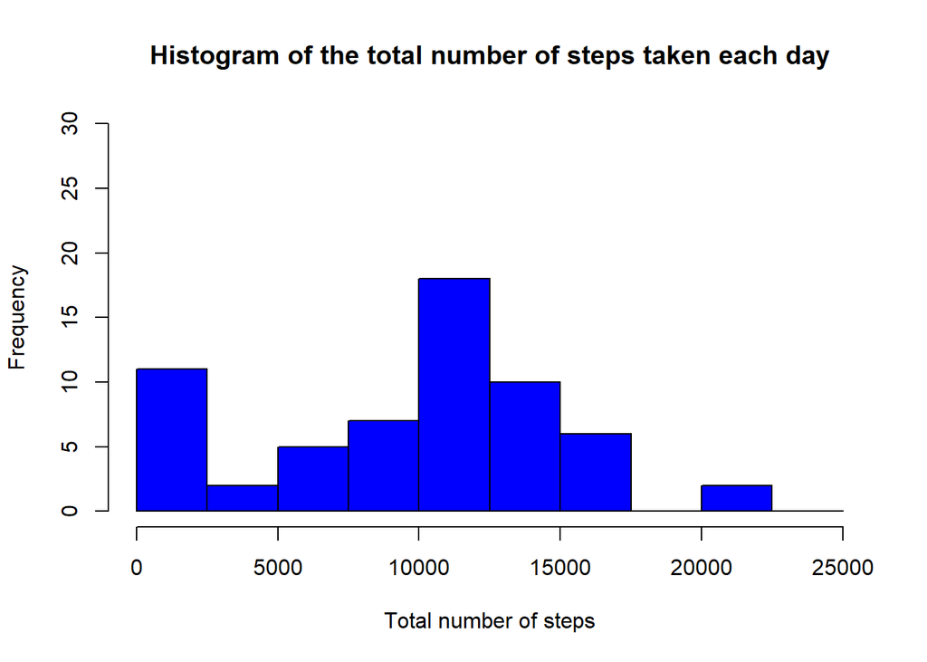

```r
# Histogram of the total number of steps taken each day.

library(tidyr)
library(dplyr)
library(ggplot2)


tot_steps <- aggregate(raw_activity$steps, by=list(raw_activity$date), FUN=sum, na.rm=TRUE)
names(tot_steps) <- c("date", "total")
hist(tot_steps$total,
     breaks=seq(from=0, to=25000, by=2500),
     col="blue",
     xlab="Total number of steps",
     ylim=c(0, 30),
     main="Histogram of the total number of steps taken each day")
```

```r
# Mean and median number of steps taken each day.

mean(tot_steps$total)
```

```
## [1] 9354.23
```

```r
median(tot_steps$total)
```

```
## [1] 10395
```

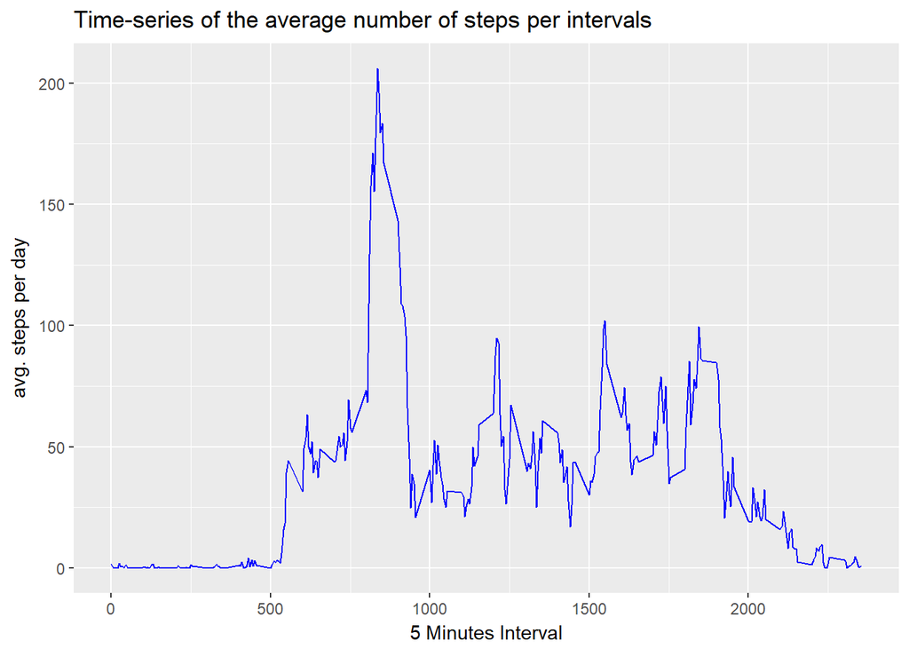

```r
# Time series plot of the average number of steps taken.

avg_steps <- aggregate(raw_activity$steps, by = list(raw_activity$interval), FUN = mean, na.rm =TRUE)


names(avg_steps) <- c("5_min_interval","avg_steps_day")

ggplot(avg_steps, aes(x= avg_steps$`5_min_interval`, y= avg_steps$avg_steps_day)) + geom_line(color= "blue") + xlab("5 Minutes Interval") + ylab("avg. steps per day") + ggtitle("Time-series of the average number of steps per intervals")
```

```r
# Which 5-minute interval that, on average, contains the maximum number of steps

filter(avg_steps, avg_steps_day == max(avg_steps$avg_steps_day))
```

```
##   5_min_interval avg_steps_day
## 1            835      206.1698
```

```r
# Code to describe and show a strategy for imputing missing data

missing_values<-sum(is.na(raw_activity))
missing_values
```

```
## [1] 2304
```

```r
# Build a histogram of the total number of steps taken each day withe the strategy of replacing the mean for the 5 minutes interval where there are missing values.

imputed_activity <- raw_activity
for (i in 1:nrow(imputed_activity))
        {
        if (is.na(imputed_activity$steps[i])) {
                interval_value <- imputed_activity$interval[i]
                steps_value <- avg_steps[avg_steps$`5_min_interval` == interval_value,]
                imputed_activity$steps[i] <- steps_value$avg_steps_day
                }
}

## Is there any NA´s in the new dataset called imputed_activity?
sum(is.na(imputed_activity$steps))
```

```
## [1] 0
```

```r
imputed_steps_day <- aggregate(steps ~ date, imputed_activity, sum)
head(imputed_steps_day)
```

```
##         date    steps
## 1 2012-10-01 10766.19
## 2 2012-10-02   126.00
## 3 2012-10-03 11352.00
## 4 2012-10-04 12116.00
## 5 2012-10-05 13294.00
## 6 2012-10-06 15420.00
```

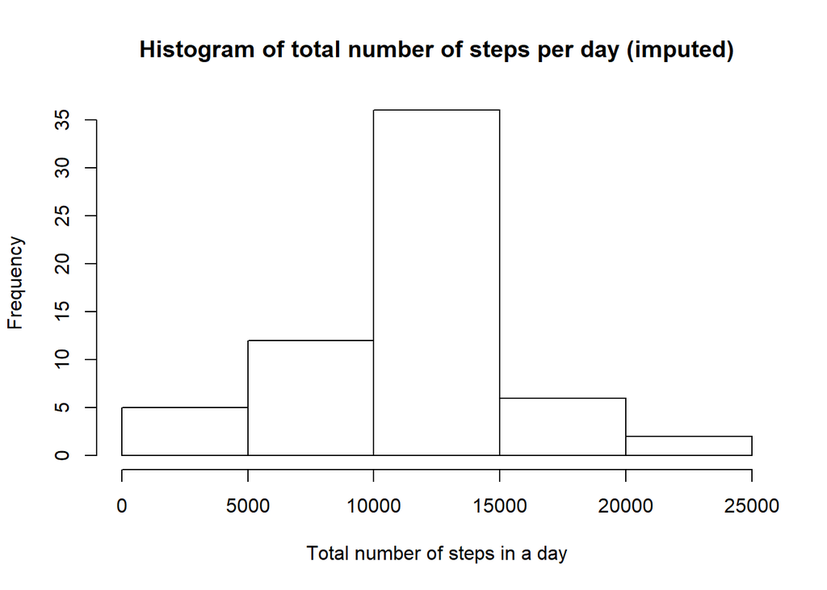

```r
hist(imputed_steps_day$steps, main="Histogram of total number of steps per day (imputed)",
     xlab="Total number of steps in a day")
```

```r
## Change weekdays/weekend type to English
Sys.setlocale("LC_TIME","English")
```

```
## [1] "English_United States.1252"
```

```r
imputed_activity["day_type"] <- weekdays(as.Date(imputed_activity$date))
imputed_activity$day_type[imputed_activity$day_type  %in% c('Saturday','Sunday') ] <- "weekend"
imputed_activity$day_type[imputed_activity$day_type != "weekend"] <- "weekday"


imputed_activity$day_type<- as.factor(as.character(imputed_activity$day_type))
str(imputed_activity)
```

```
## 'data.frame':    17568 obs. of  4 variables:
##  $ steps   : num  1.717 0.3396 0.1321 0.1509 0.0755 ...
##  $ date    : Factor w/ 61 levels "2012-10-01","2012-10-02",..: 1 1 1 1 1 1 1 1 1 1 ...
##  $ interval: int  0 5 10 15 20 25 30 35 40 45 ...
##  $ day_type: Factor w/ 2 levels "weekday","weekend": 1 1 1 1 1 1 1 1 1 1 ...
```

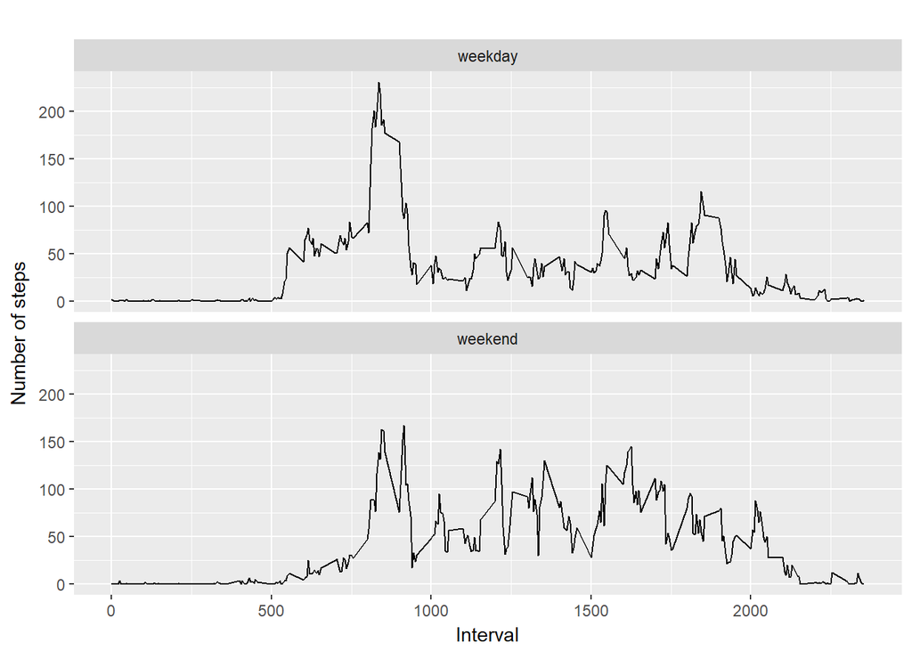

```r
# calculate average steps by interval across all days
imputed_steps_by_interval <- aggregate(steps ~ interval + day_type, imputed_activity, mean)

# creat a plot
qplot(interval,
      steps,
      data = imputed_steps_by_interval,
      type = 'l',
      geom=c("line"),
      xlab = "Interval",
      ylab = "Number of steps",
      main = "") +
  facet_wrap(~ day_type, ncol = 1)
```